# MarketDial ‘Client X’ Analysis Code

Brayden Ross

2021-05-24

## Initial Library Initialization

```r
#initialize relevant libraries
library(dplyr)
library(data.table)
library(ggplot2)
library(fastDummies)
#fast csv reading to save computing time
library(vroom)
library(gghighlight)
library(reshape2)
```

## Loading and Joining Data by Store Attributes

```r
transactions <- vroom('transactions.csv')[,-1]
store_attr <- vroom('store_attributes.csv')[,-1]
prod_int <- read.csv('products_of_interest.csv', header = FALSE)
#To be used for question 3 with pre-selected treatment and control stores
q3_treat <- read.csv('q3_treatment_stores.csv', header = FALSE)
q3_cont <- read.csv('q3_control_stores.csv', header = FALSE)
```

## Question 2

## Data Exploration and Cleaning Steps

# Exploring Dataset

```r
#Looking at number of unique store attributes under each datatype
store_attr %>%
  select(attribute_id, attribute_type) %>%
  distinct() %>%
  count(attribute_type)
```

```
## # A tibble: 3 x 2
##   attribute_type     n
##   <chr>          <int>
## 1 float             47
## 2 integer            2
## 3 string             4
```

Most attributes are float type values. There are some string values as well, lets take a look at those:

```r
store_attr %>%
  group_by(attribute_str_val) %>%
  summarise(freq = n()) %>%
  arrange(desc(freq)) %>%
  #NA values are the most common, so skip row 1
  slice(2:11)
```

```
## # A tibble: 10 x 2
##    attribute_str_val  freq
##    <chr>             <int>
##  1 ADVENTURE           229
##  2 UT                  150
##  3 White Water          89
##  4 Canyon               86
##  5 Big Snow             77
##  6 COUNTRY              75
##  7 ID                   68
##  8 Red Rock             68
##  9 WY                   34
## 10 NV                   26
```

Based on some other data sorting alphabetically, we can see there's some closed stores in the dataset:

```r
unique(sort(store_attr$attribute_str_val))[1:6]
```

```
## [1] "***CLOSED***AZ-COTTONWOOD-272"  "***CLOSED***ID-BOISE-004"
## [3] "***CLOSED***ID-BOISE-175"       "***CLOSED***ID-BOISE-206"
## [5] "***CLOSED***ID-BOISE-240"       "***CLOSED***ID-IDAHO FALLS-185"
```

Since some of the stores are closed, we want to remove all store IDs with the string attribute value '*CLOSED*' as this would likely skew our eventual PCA of the data. We don't want to include closed stores in our treatment or control groups, as they have no active revenue.

```r
remove_stores <- store_attr %>%
  filter(grepl(.$attribute_str_val,pattern = '***CLOSED***', fixed = TRUE) == TRUE) %>%
  pull(unique(store_id))
#Remove closed stores from overall dataset
store_attr <- store_attr[!store_attr$store_id %in% remove_stores,]
#Quick check to make sure operation worked as intended
for (i in remove_stores){
    print(paste0('Records for store_id ', i, ': ', sum(store_attr$store_id == i)))
}
```

```
## [1] "Records for store_id 390: 0"
## [1] "Records for store_id 468: 0"
## [1] "Records for store_id 563: 0"
## [1] "Records for store_id 602: 0"
## [1] "Records for store_id 549: 0"
## [1] "Records for store_id 405: 0"
## [1] "Records for store_id 393: 0"
## [1] "Records for store_id 552: 0"
## [1] "Records for store_id 422: 0"
## [1] "Records for store_id 601: 0"
## [1] "Records for store_id 400: 0"
## [1] "Records for store_id 364: 0"
## [1] "Records for store_id 570: 0"
## [1] "Records for store_id 655: 0"
## [1] "Records for store_id 513: 0"
## [1] "Records for store_id 381: 0"
## [1] "Records for store_id 627: 0"
```

# Store Attribute Cleaning

In order to make sure all stores included in the PCA operation are not inherently different from one another, we should make sure all stores in the sample have similar attributes. We can check this with the below plots.

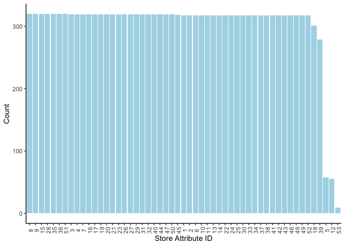

```r
store_attr %>%
  group_by(attribute_id) %>%
  summarise(freq = n()) %>%
  ggplot(aes(x = reorder(as.factor(attribute_id), -freq), y = freq)) + geom_bar(stat = 'identity', fill = 'lightblue') + xlab('Store Attribute ID') + ylab('Count') + theme_bw() + theme(panel.border = element_blank(),axis.text.x = element_text(angle = 90, hjust=0.5, vjust = 0.8), panel.grid.major = element_blank(),
panel.grid.minor = element_blank(), axis.line = element_line(colour = "black"))#+ gghighlight(freq < 168.5)
```

As suspected, it looks like some attributes are only included in a small number of stores.

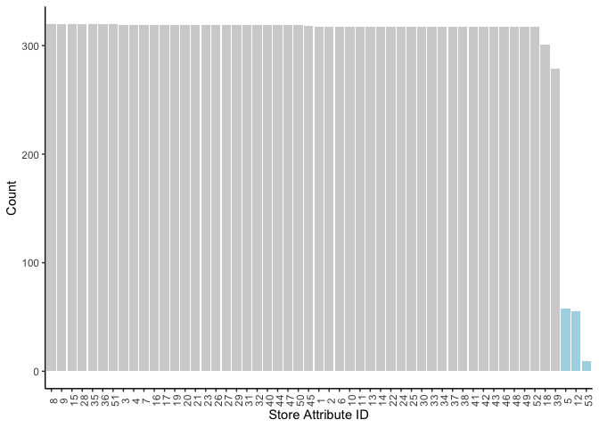

```r
#Highlights store attributes in less than half the included stores
store_attr %>%
  group_by(attribute_id) %>%
  summarise(freq = n()) %>%
  ggplot(aes(x = reorder(as.factor(attribute_id), -freq), y = freq)) + geom_bar(stat = 'identity', fill = 'lightblue') + gghighlight(freq < 168.5) + xlab('Store Attribute ID') + ylab('Count')+ theme_bw() + theme(axis.text.x = element_text(angle = 90, hjust=0.5, vjust = 0.8), panel.border = element_blank(), panel.grid.major = element_blank(),
panel.grid.minor = element_blank(), axis.line = element_line(colour = "black"))
```

Attributes 5, 12 and 53 are in less than half the included stores, meaning they are unique to a few special locations. We may want to remove these **attributes** from the dataset, but not the stores altogether. There are other valuable features within the dataset relating to other attributes for those stores.

Before we think about removing them, let's take a look at what those attributes actually relate to.

```r
store_attr %>%
  select(attribute_id, attribute_type) %>%
  filter(.$attribute_id %in% c(5,12,23)) %>%
  distinct() %>%
  arrange(attribute_id)
```

```
## # A tibble: 3 x 2
##   attribute_id attribute_type
##          <dbl> <chr>
## 1            5 float
## 2           12 float
## 3           23 float
```

```r
#All floats, let's count how many records there are for each attribute
store_attr %>%
  select(attribute_id, attribute_type) %>%
  filter(.$attribute_id %in% c(5, 12, 23)) %>%
  group_by(attribute_id) %>%
  summarise(freq = n())
```

```
## # A tibble: 3 x 2
##   attribute_id  freq
##          <dbl> <int>
## 1            5    58
## 2           12    55
## 3           23   319
```

Because they are floats and not string values, and because we don't know directly what they relate to, we should probably leave them. Client X may want to keep these characteristics in the selection process because they know they're related to some significant defining features of a subgroup of locations that they're interested in understanding more about. With non-hashed information we could make a better determination on whether to include these features or not but for now we'll leave them.

## Perfect Ignorance Approach to Selection of Test and Control Groups

Now that we've done some initial exploration and cleaning of the attributes dataset, we want to gather more info on the stores characteristics and attributes to do a PCA on. This will be a critical part of our eventual selection method using some other clustering and iterative methods. First we need to get the data into the right format for the store characteristics.

```r
#Checking to make sure all rows only have one non-na value in them
sum(rowSums(is.na(store_attr[,c(4:6)]))) == nrow(store_attr) * 2
```

```
## [1] TRUE
```

```r
#Gather non-na value into one column to melt over store_id and attributes for PCA analysis
store_attr$value <- apply(store_attr[,c(4:6)], 1, function(i) ifelse(all(is.na(i)), NA, i[!is.na(i)]))
#Save store attribute types and attribute ids for later
attrib_ids <- unique(store_attr[,c(2:3)])
#Remove attribute columns that have now been replaced by single value column
store_attr <- store_attr[,-c(3:6)]
#Now cast data into format ready for PCA
test_cast <- dcast(store_attr, store_id ~ attribute_id)
#Gather vectors of column indices for different datatypes (add 1 because first column is store_id)
int_cols <- attrib_ids %>% filter(attribute_type == 'integer') %>% pull(attribute_id) + 1
num_cols <- attrib_ids %>% filter(attribute_type == 'float') %>% pull(attribute_id) + 1
char_cols <- attrib_ids %>% filter(attribute_type == 'string') %>% pull(attribute_id) + 1
#Change column classes based on data types found previously from dataframe
test_cast[int_cols] <- lapply(test_cast[int_cols], as.integer)
test_cast[num_cols] <- lapply(test_cast[num_cols], as.numeric)
test_cast[char_cols] <- lapply(test_cast[char_cols], as.character)
#Replace NA values
test_cast[,c(int_cols, num_cols)][is.na(test_cast[, c(int_cols, num_cols)])] <- 0
test_cast[,char_cols][is.na(test_cast[,char_cols])] <- 'Not Applicable'
#We can remove variable 51 because the store attribute for location is completely unique to the store_id
length(unique(test_cast$`51`))
```

```
## [1] 320
```

```r
test_cast <- test_cast %>% select(-`51`)
#Use fastDummies package to create dummy variables for the character columns
test_cast <- dummy_cols(test_cast)
#Remove character columns
test_cast <- test_cast[,-char_cols]
```

Our data has been cast into the proper format now, and we have the opportunity to merge it with our transaction data for the final PCA. We have dummy columns for the categorical and string variables, and all our information is on a store-by-store basis, which will allow for clustering to pick stores for treatment and control groups.

# Transaction Data

Now we can move on to cleaning the transaction data for the PCA. We want to find out a few things about the revenues of the stores in the preliminary period (i.e. when the test isn't being conducted or set up):

- The average product category revenue for the relevant product categories (Brand Z)
- The variance for the product category revenue for Brand Z at the locations
- The overall average revenue for the location
- The variance for the overall revenue for the location
- The percentage of overall revenue that the relevant product category makes up at each location.

These types of details will help us cluster our stores when selecting our treatment and control groups, in addition to the store attributes from before.

First, we subset the data for the relevant time frame and then generate some new variables.

```r
transactions$date_week <- as.Date(transactions$date_week, format = '%Y-%m-%d')
prod_avg <- transactions %>%
  filter(date_week <= as.Date('2016-10-15', format = '%Y-%m-%d') & date_week >= as.Date('2016-07-17', format = '%Y-%m-%d') & product_id %in% prod_int$V1) %>%
  group_by(store_id) %>%
  summarise(avg_product_rev = mean(revenue),
            product_var = var(revenue),
            total_prod_rev = sum(revenue))


store_avg <- transactions %>%
  filter(date_week <= as.Date('2016-10-15', format = '%Y-%m-%d') & date_week >= as.Date('2016-07-17', format = '%Y-%m-%d')) %>%
  group_by(store_id) %>%
  summarise(total_store_rev = sum(revenue),
            avg_store_rev = mean(revenue),
            total_store_var = var(revenue))

trans_chars <- merge(store_avg, prod_avg, by = 'store_id')
#remove data for speed optimization
rm(store_avg, prod_avg)
#Add percent of total revenue for product category included
trans_chars <- trans_chars %>%
  mutate(pct_prod = round(total_prod_rev/total_store_rev, 2))
```

Now it's finally time to merge and scale our data. We have both the transaction data and the store attribute information, and we can conduct our relevant statistical selection for the treatment and control groups.

Due to the nature of this approach, we're assuming no prior knowledge of experiments done for client X in the past. This means we have no knowledege of which factors impact their likelihood of lift the most, or what types of cost/revenue drivers are the most important. These things would likely warrant a different method if they were known, but for our case, a principle component analysis with some other pre-processing will do the trick.

We kept our categorical variables from before, but converted them into dummies. This was done to allow for that information to be scaled with the rest of the store characteristics and the transaction data. Let's merge and scale the information we have.

```r
trans_attr <- merge(test_cast, trans_chars, by = 'store_id')
#Remove comparison dummy cols and also all 0 column
trans_attr <- trans_attr %>% select(-c(`39`,`9_SD`))
trans_attr[,c(2:length(trans_attr))] <- as.data.frame(scale(trans_attr[,c(2:length(trans_attr))], center = TRUE))
```

Now that the data is centered and scaled, we can use the information gathered from the stores to cluster them in groups for sampling. There are numerous clustering algorithms and methods available, but for this analysis a Same Size K-means cluster method was selected. This allows for groups of equal sizes to be determined, ensuring we have a balanaced control set to pull from while also still detecting meaningful features that make up our groups to pull a treatment from.

We can initialize the clustering using this function:

```r
kmvar <- function(mat, clsize=10, method=c('random','maxd', 'mind', 'elki')){
  k = ceiling(nrow(mat)/clsize)
  km.o = kmeans(mat, k)
  labs = rep(NA, nrow(mat))
  centd = lapply(1:k, function(kk){
    euc = t(mat)-km.o$centers[kk,]
    sqrt(apply(euc, 2, function(x) sum(x^2)))
  })
  centd = matrix(unlist(centd), ncol=k)
  clsizes = rep(0, k)
  if(method[1]=='random'){
    ptord = sample.int(nrow(mat))
  } else if(method[1]=='elki'){
    ptord = order(apply(centd, 1, min) - apply(centd, 1, max))
  } else if(method[1]=='maxd'){
    ptord = order(-apply(centd, 1, max))
  } else if(method[1]=='mind'){
    ptord = order(apply(centd, 1, min))
  } else {
    stop('unknown method')
  }
  for(ii in ptord){
    bestcl = which.max(centd[ii,])
    labs[ii] = bestcl
    clsizes[bestcl] = clsizes[bestcl] + 1
    if(clsizes[bestcl] >= clsize){
      centd[,bestcl] = NA
    }
  }
  return(labs)
}
```

Now that we've initialized our function, we can create the principal component analysis for explaining the variance among the store locations based on both the attributes and the relevant transaction characteristics.

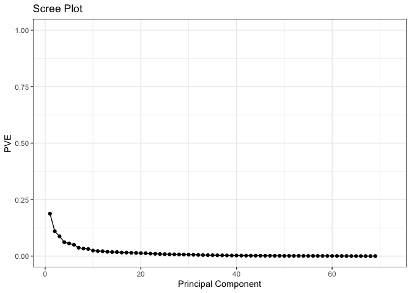

```r
test_cov <- cov(trans_attr[,-1])
test_eigen <- eigen(test_cov)
pca_test <- prcomp(trans_attr[,-1])
store_ids <- trans_attr[,1]
PVE <- test_eigen$values / sum(test_eigen$values)
PVEplot <- qplot(c(1:72), PVE) +
  geom_line() +
  xlab("Principal Component") +
  ylab("PVE") +
  ggtitle("Scree Plot") +
  ylim(0, 1) + theme(panel.border = element_blank(), panel.grid.major = element_blank(), axis.line = element_line(colour = "black")) + theme_bw()
PVEplot
```

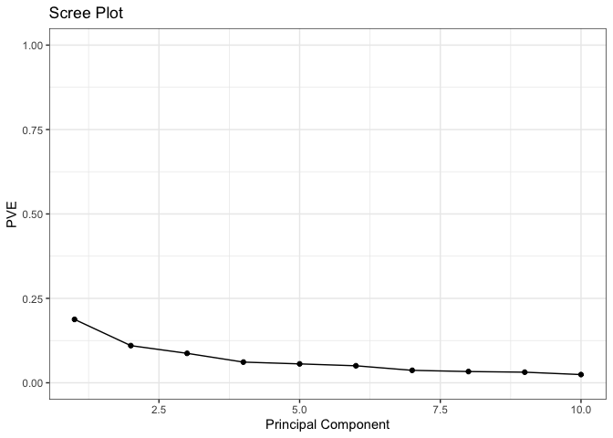

```r
PVE_slice <- PVE[1:10]
PVEplot <- qplot(c(1:10), PVE_slice) +
  geom_line() +
  xlab("Principal Component") +
  ylab("PVE") +
  ggtitle("Scree Plot") +
  ylim(0, 1) + theme(panel.border = element_blank(), panel.grid.major = element_blank(), axis.line = element_line(colour = "black")) + theme_bw()
PVEplot
```

As shown in the two graphs above, there is a significant amount of loss in variance explained past the first 6 principal components, so we will only use the first 6 for this case.

```r
pca_test <- pca_test$x[,1:6]
```

Because of the nature of the selection method, we need to determine the right number of clusters for our algorithm based on the sample size. We can do this through a weighted mean computation for the relevant category revenue information. This will give us the required sample size to conduct a robust experiment.

```r
stderrtest <- transactions %>%
  filter(date_week <= as.Date('2016-11-12', format = '%Y-%m-%d') & date_week >= as.Date('2016-07-17', format = '%Y-%m-%d') & product_id %in% prod_int$V1) %>%
  group_by(store_id) %>%
  summarise(stdevprod = sd(revenue),
            prod_avg =  mean(revenue),
            stdevtot = stdevprod/prod_avg)
wghtmean <- weighted.mean(stderrtest$stdevtot, stderrtest$prod_avg)

sampsize <- function(stdev, marg, critval) {
  return (((critval * stdev)/(marg))^2)
}

required_sample <- sampsize(wghtmean, .20, 0.841)
cluster_size <- round(nrow(pca_test)/ required_sample)
cluster_results <- kmvar(pca_test, clsize = cluster_size)
final <- as.data.frame(pca_test)
```

For this arbitrary test, a confidence level of 60% was chosen, with an interval of 20%. The level of confidence was chosen because the average standard deviation for the candy is small, further eluding to the fact that we may only have all candy data provided rather than whole store data. Using this test, we have approximately 10 stores per cluster, giving us an equal distribution of stores over the explored variance based on characteristics and transaction data.

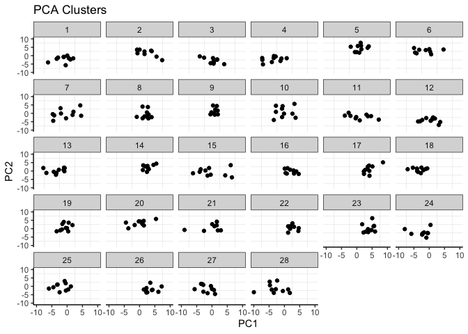

```r
ggplot(data = final, aes(x = PC1, y = PC2)) + geom_point() +
  xlim(c(-10,10)) + ylim(c(-10, 10)) + facet_wrap(~ factor(cluster_results)) + theme_bw() + theme(panel.border = element_blank(), panel.grid.major = element_blank(), axis.line = element_line(colour = "black")) + labs(title = 'PCA Clusters')
```

Based on the confidence levels and the results provided, we have 28 clusters among the data.

Now that we have our store clusters, we can choose our treatment and control groups. Based on the information provided, we can choose a store that is closest to the median characteristics of the group its been assigned to. We can then highlight the control and treatment groups in the plot above to get a better idea of where our experiment will happen based on the variations in the plot above.

```r
trans_attr$cluster <- cluster_results

median_chars <- trans_attr %>%
  select(-store_id) %>%
  group_by(cluster) %>%
  summarise(across(everything(), median))
#Gather row sums for median characteristics
median_chars$sum <- rowSums(median_chars[,1:length(median_chars)])
median_chars <- median_chars[,c(1,74)]
#Merge back into trans_chars data
trans_attr <- merge(trans_attr, median_chars, by = 'cluster')
trans_attr$sum2 <- rowSums(trans_attr[,3:74])

treat_stores <- trans_attr %>%
  group_by(cluster) %>%
  filter(abs(sum2 - sum) == min(abs(sum2 - sum))) %>%
  select(cluster, store_id)
treat_stores$is_treat <- 1
trans_attr <- merge(trans_attr, treat_stores, all.x = TRUE, by = c('store_id', 'cluster'))
trans_attr$is_treat[is.na(trans_attr$is_treat)] <- 0

cont_stores <- trans_attr[trans_attr$is_treat != 1,] %>%
  group_by(cluster) %>%
  filter(abs(sum2 - sum) == min(abs(sum2 - sum)) ) %>%
  select(cluster, store_id)
cont_stores$is_cont <- 2

trans_attr <- merge(trans_attr, cont_stores, all.x = TRUE, by = c('store_id', 'cluster'))
trans_attr$is_cont[is.na(trans_attr$is_cont)] <- 0
trans_attr$store_type <- rowSums(trans_attr[,c('is_cont','is_treat')])
trans_attr <- trans_attr %>% select(-is_cont, -is_treat)
```

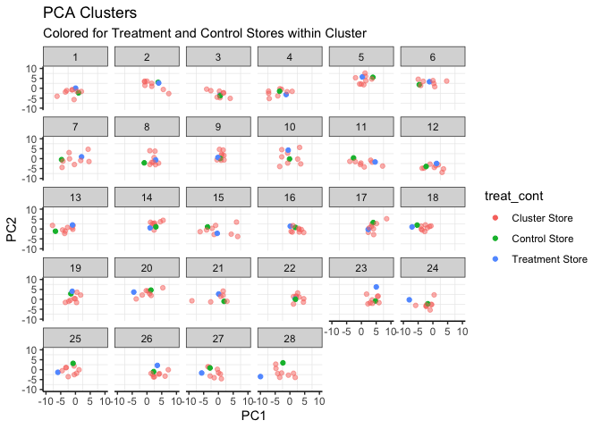

```r
final$treat_cont <- trans_attr$store_type
final$treat_cont <- as.factor(ifelse(final$treat_cont == 0, 'Cluster Store', ifelse(final$treat_cont == 1, 'Treatment Store', 'Control Store')))
ggplot(data = final, aes(x = PC1, y = PC2)) + geom_point(aes(color = treat_cont, alpha = treat_cont == 'Cluster Store')) + scale_alpha_manual(values = c(1, 0.5), guide = FALSE) +
  xlim(c(-10,10)) + ylim(c(-10, 10)) + facet_wrap(~ factor(cluster_results)) + theme_bw() + theme(panel.border = element_blank(), panel.grid.major = element_blank(), axis.line = element_line(colour = "black")) + labs(title = 'PCA Clusters', subtitle = 'Colored for Treatment and Control Stores within Cluster')
```

Highlighted above are the clusters based on the principal components, and within them the respective treatment and control stores. The selected treatment and control stores are as follows:

| Cluster | Treatment Store | Control Store |
| --- | --- | --- |
| 1 | 355 | 365 |
| 2 | 466 | 401 |
| 3 | 477 | 568 |
| 4 | 347 | 493 |
| 5 | 451 | 482 |
| 6 | 415 | 430 |
| 7 | 354 | 339 |
| 8 | 533 | 443 |
| 9 | 629 | 541 |
| 10 | 510 | 416 |
| 11 | 673 | 413 |
| 12 | 571 | 643 |
| 13 | 586 | 489 |
| 14 | 519 | 620 |

| Cluster | Treatment Store | Control Store |
| --- | --- | --- |
| 15 | 637 | 562 |
| 16 | 439 | 476 |
| 17 | 640 | 429 |
| 18 | 583 | 534 |
| 19 | 535 | 505 |
| 20 | 606 | 605 |
| 21 | 455 | 395 |
| 22 | 559 | 630 |
| 23 | 529 | 459 |
| 24 | 553 | 579 |
| 25 | 375 | 597 |
| 26 | 398 | 626 |
| 27 | 511 | 572 |
| 28 | 384 | 424 |

## Question 3

Before we attempt any statistical analysis of the data presented for this test period, we first must clean the data so it has the appropriate time frames as well as ensure we only include the relevant store_id records. The treatment and control groups are labeled among the transaction data, as for this question we won't be needing the attribute data. A visualization of the data plotted over the given time frame colored by time period and faceted by treatment vs. control is shown below:

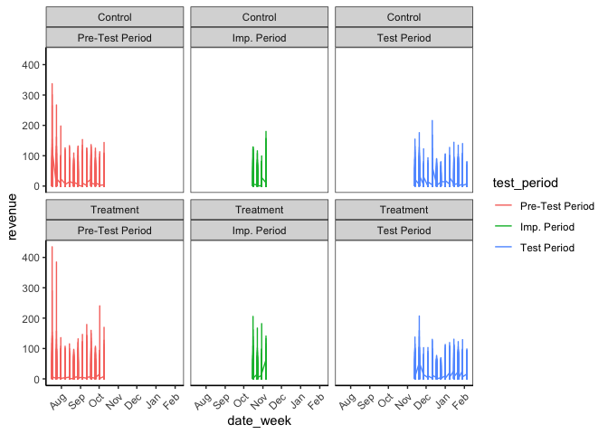

```r
trans_q3 <- transactions %>%
  filter(store_id %in% q3_treat$V1 | store_id %in% q3_cont$V1 & product_id %in% prod_int$V1) %>%
  mutate(store_type = ifelse(store_id %in% q3_treat$V1, 'Treatment', 'Control'))

trans_q3 <- trans_q3 %>%
  filter(date_week >='2016-07-17' & date_week < '2017-02-12') %>%
  mutate(test_period = ifelse(date_week >= '2016-07-17' & date_week <= '2016-10-15', 'Pre-Test Period', ifelse(date_week >= '2016-10-16' & date_week <= '2016-11-12', 'Imp. Period', 'Test Period')))
trans_q3$test_period = factor(trans_q3$test_period, levels=c('Pre-Test Period', 'Imp. Period', 'Test Period'))

ggplot(data= trans_q3, aes(x = date_week, y = revenue)) + geom_line(aes(color =test_period)) + scale_x_date(date_breaks = "1 month", date_labels = "%b") + facet_wrap(~store_type + test_period) + theme_bw() + theme(axis.text.x = element_text(angle = 45, hjust = 1), panel.grid.major = element_blank(),
panel.grid.minor = element_blank(), axis.line = element_line(colour = "black"))
```

In order to gather as much information about our sales periods, we should look to see how many weeks are in both the pre-test and test period, this way we can determine if there's a large enough baseline to use for the pre-test transaction data. This is assuming we're ignoring confounding effects, such as seasonality, weather, holidays and more.

```r
trans_q3 %>%
  group_by(test_period) %>%
  summarise('Num of Weeks' = length(unique(date_week)))
```

```
## # A tibble: 3 x 2
##   test_period     `Num of Weeks`
##   <fct>                    <int>
## 1 Pre-Test Period             13
## 2 Imp. Period                  4
## 3 Test Period                 13
```

The number of weeks between the pre-test period given and the test period are exactly equal. We can use these comparable time periods again by assuming we're ignoring confounding factors. These weeks and time periods could include high-traffic months, holidays, weather affections, etc. that may change the results inherently. We can determine whether or not this effect is evident by running some tests and examining the data further.

Before we calculate the lift in the sales for Brand Z's candy, we need to determine which test of significance we should use. We first need to look at the distribution of the revenue data.

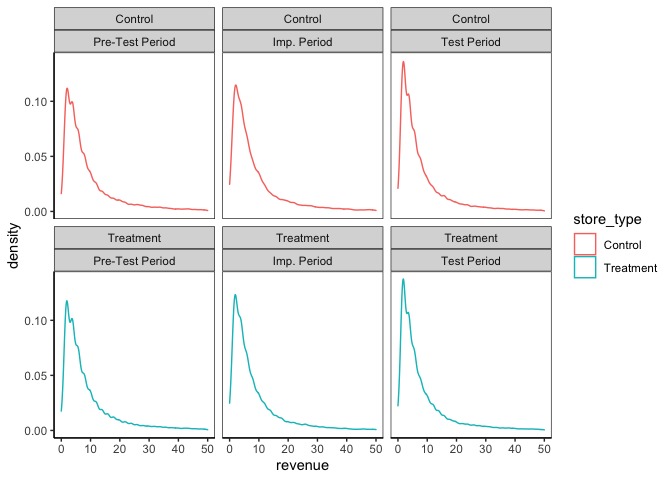

```r
ggplot(trans_q3, aes(x = revenue, color = store_type)) +
  geom_density() + xlim(0,50) + facet_wrap(~store_type + test_period) + theme_bw() + theme(panel.grid.major = element_blank(),
panel.grid.minor = element_blank(), axis.line = element_line(colour = "black"))
```

As suspected, because this is sales data, it doesn't follow a normal distribution. This means that testing for statistical signficance using inference tests that assume a normal distribution of data would be innacurate and nullify our results. We instead should use a test of significance that allows for a non-conforming distribution of data.

It is interesting to note that the distributions for the different time periods included are almost identical to each other.

```r
base_comp <- trans_q3 %>%
  group_by(date_week, store_id, test_period, store_type) %>%
  summarise(brand_z_rev = sum(revenue))
base_comp <- base_comp %>% group_by(test_period) %>% mutate(week_num = match(date_week, unique(date_week)))

pre_test <- base_comp %>% select(week_num, store_id, brand_z_rev, store_type) %>% filter(test_period == 'Pre-Test Period')
test <- base_comp %>% select(week_num, store_id, brand_z_rev, store_type) %>% filter(test_period == 'Test Period')

overall <- merge(pre_test, test, by = c('store_id', 'week_num'))
overall <- overall[,-c(3,5,6)]
colnames(overall) <- c('store_id', 'week_num', 'pre_test_rev', 'test_rev', 'store_type')
overall$inc_sales_lift <- (overall$test_rev - overall$pre_test_rev)/overall$test_rev

cont_base_rev <- overall %>% filter(store_type == 'Control') %>% pull(inc_sales_lift)
treat_base_rev <- overall %>% filter(store_type == 'Treatment') %>% pull(inc_sales_lift)

means_1 <- c(mean(treat_base_rev), mean(cont_base_rev))
```

Now that we've defined the relevant data points for our lift in revenue analysis, we can use a Wilcoxon Rank Sum test to determine whether there was a significant change in the treatment vs. the control stores using the pre-test period revenue data as a baseline for both.

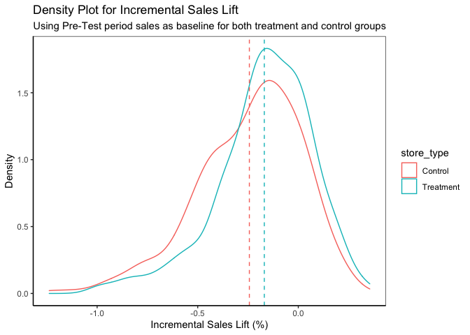

```r
ggplot(overall, aes(x = inc_sales_lift, color = store_type)) +
  geom_density() + theme_bw() + theme(panel.grid.major = element_blank(),
panel.grid.minor = element_blank(), axis.line = element_line(colour = "black")) + geom_vline(xintercept = means_1, linetype = 'dashed', color = c('#00BFC4','#F8766D')) + labs(title = 'Density Plot for Incremental Sales Lift',subtitle ='Using Pre-Test period sales as baseline for both treatment and control groups') + ylab('Density') + xlab('Incremental Sales Lift (%)')
```

After examining the density plot, it looks like there was mainly a decrease in overall revenue lift during the test period while using the pre-test period as a baseline. Both the treatment and control stores were mainly centered below 0% revenue lift, leading to the conjecture that some of the confounding factors mentioned before may be having a larger impact on the relevant test data period than we had anticipated.

We can test for this again with the Wilcoxon rank sum test, using an alternative hypothesis to gather whether the treatment incremental sales lift over the pre-test period was greater than the control incremental sales lift over the pre-test period.

```r
wilcox.test(treat_base_rev, cont_base_rev, data = overall, alternative = 'greater')
```

```
##
##  Wilcoxon rank sum test with continuity correction
##
## data:  treat_base_rev and cont_base_rev
## W = 61630, p-value = 0.0001151
## alternative hypothesis: true location shift is greater than 0
```

Based on the p-value, we can determine that there was a statistically significant shift in the treatment stores' incremental sales lift over the pre-test period compared to the control stores' incremental sales lift over the pre-test period. However, the average lift is still centered below 0, leading us to believe that this may not be the best choice for Client X to roll out in their stores when using the Pre-Test period as a baseline. To get a final conclusion we should look at the overall revenue lift from week-to-week over the test period.

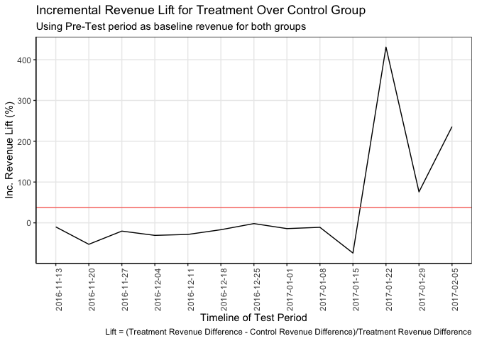

```r
overall$sales_diff <- overall$test_rev - overall$pre_test_rev
cont_pre <- overall %>% group_by(week_num) %>% filter(store_type == 'Control') %>% summarise(control_rev = sum(sales_diff))
treat_pre <- overall %>% group_by(week_num) %>% filter(store_type == 'Treatment') %>% summarise(treatment_rev = sum(sales_diff))

pre_overall <- merge(treat_pre, cont_pre, by = c('week_num'))
pre_overall$inc_rev_lift <- (pre_overall$treatment_rev - pre_overall$control_rev)/pre_overall$treatment_rev * 100

pre_test <- base_comp %>%
  filter(test_period == 'Test Period') %>%
  group_by(date_week, store_id, store_type, week_num) %>%
  summarise(brand_z_rev = sum(brand_z_rev))


pre_overall <- merge(pre_overall, distinct(pre_test[,c(1,4)]), all.y = FALSE, by = 'week_num')

ggplot(data= pre_overall, aes(x = date_week, y = inc_rev_lift)) + geom_line() + scale_x_date(breaks = seq(min(pre_overall$date_week),max(pre_overall$date_week),by="week")) + geom_hline(aes(yintercept = mean(pre_overall$inc_rev_lift)), color = '#F8766D') + theme_bw() + theme(axis.text.x = element_text(angle = 90, hjust = 1), panel.grid.minor = element_blank(), axis.line = element_line(colour = "black")) + ylab('Inc. Revenue Lift (%)') + xlab('Timeline of Test Period') + labs(title = 'Incremental Revenue Lift for Treatment Over Control Group', subtitle = 'Using Pre-Test period as baseline revenue for both groups', caption = 'Lift = (Treatment Revenue Difference - Control Revenue Difference)/Treatment Revenue Difference')
```

As we can see from the plot above, using the pre-test period as a baseline to compare our treatment and control stores in the test period to presents some very skewed results. For much of the test period, the stores are performing worse compared to the baseline period, but towards the end they experience huge shifts in revenue lift. This isn't a reliable result, as the sudden and drastic changes are likely related to confounding factors. Using these inferences, we can safely say that using the pre-test period as a baseline is not the best idea in this case.

It should be noted that a baseline approach is not completely invalid, it may just have to be the same time periods for previous years. Using a different set of time for a baseline presents some bias in the results that would likely not be present if the same time period the test took place was used as a baseline from the year(s) previous.

# Test Period Only

Now that we know not to use a baseline from the pre-test period, we should run the same tests only using the test period to compare the treatment and control groups. Based on our previous findings, this will likely give us our most robust results. Let's perform the same operations as we did previously, this time only using the revenue from the test period.

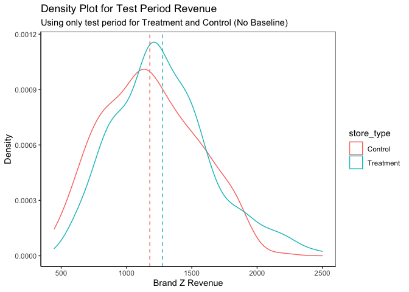

```r
test_only <- base_comp %>%
  filter(test_period == 'Test Period') %>%
  group_by(date_week, store_id, store_type, week_num) %>%
  summarise(brand_z_rev = sum(brand_z_rev))

cont_rev <- test_only %>% filter(store_type == 'Control') %>% pull(brand_z_rev)
treat_rev <- test_only %>% filter(store_type == 'Treatment') %>% pull(brand_z_rev)
means <- c(mean(treat_rev), mean(cont_rev))
ggplot(test_only, aes(x = brand_z_rev, color = store_type)) +
  geom_density() + theme_bw() + theme(panel.grid.major = element_blank(),
panel.grid.minor = element_blank(), axis.line = element_line(colour = "black")) + geom_vline(xintercept = means, linetype = 'dashed', color = c('#00BFC4','#F8766D')) + labs(title = 'Density Plot for Test Period Revenue',subtitle = 'Using only test period for Treatment and Control (No Baseline)') + ylab('Density') + xlab('Brand Z Revenue')
```

As we can see from the density plot above, the revenue for the treatment stores looks to be centered to the right of the control stores, leading us to believe that the treatment stores gained more revenue over the test period than the control stores.

As always, we need to test this using the Wilcoxon Rank Sum test to determine if there is a statistically significant shift between the two groups.

```r
wilcox.test(treat_rev, cont_rev, data = test_only, alternative = 'greater')
```

```
##
##  Wilcoxon rank sum test with continuity correction
##
## data:  treat_rev and cont_rev
## W = 60012, p-value = 0.001318
## alternative hypothesis: true location shift is greater than 0
```

Based on the p-value and the nature of the alternative hypothesis, we can determine that the treatment revenue had a statistically significant shift to the right of the control group revenue. This means that there was a statistically significant lift in treatment stores who changed their displays for Brand Z's candy over control stores who did not.

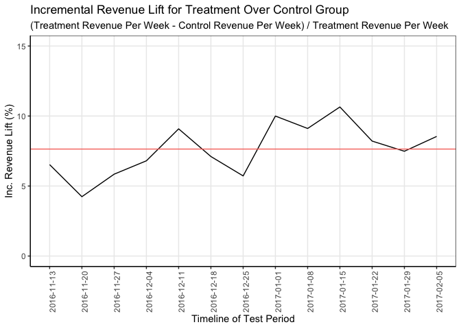

```r
cont_test <- test_only %>% group_by(week_num) %>% filter(store_type == 'Control') %>% summarise(control_rev = sum(brand_z_rev))
treat_test <- test_only %>% group_by(week_num) %>% filter(store_type == 'Treatment') %>% summarise(treatment_rev = sum(brand_z_rev))

test_overall <- merge(treat_test, cont_test, by = c('week_num'))
test_overall$inc_rev_lift <- (test_overall$treatment_rev - test_overall$control_rev)/test_overall$treatment_rev * 100

test_overall <- merge(test_overall, distinct(test_only[,c(1,4)]), all.y = FALSE, by = 'week_num')

ggplot(data= test_overall, aes(x = date_week, y = inc_rev_lift)) + geom_line() + scale_x_date(breaks = seq(min(test_overall$date_week),max(test_overall$date_week),by="week")) + geom_hline(aes(yintercept = mean(test_overall$inc_rev_lift)), color = '#F8766D') + theme_bw() + theme(axis.text.x = element_text(angle = 90, hjust = 1), panel.grid.minor = element_blank(), axis.line = element_line(colour = "black")) + ylab('Inc. Revenue Lift (%)') + xlab('Timeline of Test Period') + labs(title = 'Incremental Revenue Lift for Treatment Over Control Group', subtitle = '(Treatment Revenue Per Week - Control Revenue Per Week) / Treatment Revenue Per Week') + ylim(0,15)
```

The average incremental revenue lift for the test period between the treatment stores and the control stores is 7.64%. This means that over the course of the experiment, changing the signs and displays for Brand Z's candy increased incremental revenue by almost 8% on average.

Based on this information, if Client X's MDE was below 8%, we'd recommend rolling out the display changes company-wide.